# DEJU Playback Study Data Analysis

Author

Eleanor, Kobe, Liam, Dave

# Setup

Load the packages used for data wrangling, date-time handling, summaries, and plotting.

# Build the Annotation-Level Dataset

## Identify Annotation Files

List the `.txt` annotation files in the repositories `data` directory.

```r
data_files = list.files("data")
data_files = data_files[str_detect(data_files, "\\.txt$")]
```

## Import and Combine Annotation Files

Import each annotation file, calculate annotation duration, extract trial metadata, from the file name, and carry forward the most recent focal-male distance estimate.

```r
# Create an empty data frame (tibble) that will eventually contain the full data set.
deju_data = tibble()

# Begin a for loop to iterate through each file in the file list.
for(i in 1:length(data_files)) {

# Read in a data file, labeling the columns correctly.
  dejuraw = as_tibble(
    read.table(
      paste0("data/", data_files[i]),
      sep = "\t",
      quote = "",
      col.names = c("onset", "offset", "annotation")
      )
    )

  deju_rtj = dejuraw %>%
# Calculate annotation duration
    mutate(duration = offset - onset) %>%
    relocate(duration, .after = offset) %>%
# Add the source file name and extract trial metadata.
    mutate(file_name = str_remove(data_files[i], "\\.txt$")) %>%
    separate_wider_delim(
      col = file_name,
      delim = "_",
      names = c("recording_date", "recording_start_time", "bands", "treatment")) %>%
# Format trial date and start time.
    mutate(recording_date = ymd(recording_date),
      recording_start_time = str_replace(
        recording_start_time,
        "(\\d\\d)(\\d\\d)",
        "\\1:\\2"),
      datetime = as.POSIXct(
        paste(recording_date, recording_start_time),
        tz = "America/St_Johns"
        )
      ) %>%
    relocate(datetime, .before = recording_start_time) %>%
# Extract and carry forward focal-male distance estimates.
    mutate(
      estimated_distance_of_focal_male = if_else(
        str_detect(annotation, "^\\d+m$"),
        str_remove(annotation, "m$"),
        NA_character_
      )
    ) %>%
    fill(estimated_distance_of_focal_male, .direction = "down") %>%
    mutate(estimated_distance_of_focal_male = as.numeric(estimated_distance_of_focal_male)) %>%
    select(-recording_start_time)

  deju_data = bind_rows(deju_data, deju_rtj)
}
```

# Derive Trial-Level Variables

Each section below reduces the annotation-level data to one response or trial descriptor per bird per treatment.

## Trial Date and Time

Extract the date and start time associated with each trial.

```r
date_and_time = deju_data %>%
  group_by(bands, treatment) %>%
  summarise(
    date_of_trial = first(as_date(datetime)),
    time_of_trial = first(format(datetime, "%H:%M:%S")),
    .groups = "drop") %>%
  mutate(time_of_trial = as_hms(time_of_trial))
```

## Number of Songs

Count focal-male song annotations in each trial.

```r
songs = deju_data %>%
  filter(str_detect(annotation, "Focalsong")) %>%
  group_by(bands, treatment) %>%
  summarise(number_of_songs = n(), .groups = "drop")
```

## Minimum Distance

Calculate the closest recorded distance to the playback speaker in each trial. Trials without a distance estimate remain `NA`.

```r
minimum_distance = deju_data %>%
  group_by(bands, treatment) %>%
  summarise(
    minimum_distance = if(all(is.na(estimated_distance_of_focal_male))) {
      NA_real_
  } else {
    min(estimated_distance_of_focal_male, na.rm = TRUE)
  },
  .groups = "drop"
  )
```

## Time to Approach Within 10 Metres

Calculate elapsed time from playback start to the first recorded distance at or within 10 metres.

```r
time_to_10m = deju_data %>%
  group_by(bands, treatment) %>%
  summarise(
    pbstart_time = first(onset[annotation == "Pbstart"]),
    first_time_within_10 = if_else(any(estimated_distance_of_focal_male <= 10, na.rm = TRUE),
     first(onset[estimated_distance_of_focal_male <= 10], na_rm = TRUE),
     NA_real_),
    time_to_approach_10m = first_time_within_10 - pbstart_time,
    .groups = "drop"
  )
```

## Time Spent Within 10 Metres

Estimate the total time spent within 10 metres from successive crossings of the 10 metre boundary

```r
time_within_10_metres = deju_data %>%
  group_by(bands, treatment) %>%
  mutate(
    previous_distance = lag(estimated_distance_of_focal_male),
    next_distance = lead(estimated_distance_of_focal_male),
    move = if_else(
      estimated_distance_of_focal_male <= 10 &
        (previous_distance > 10 | is.na(previous_distance)) |
        estimated_distance_of_focal_male > 10 & previous_distance <= 10,
      "yes",
      "no"
      )
    ) %>%
  filter(move == "yes") %>%
  mutate(
    direction = if_else(
      previous_distance > estimated_distance_of_focal_male,
      "in",
      "out"
      ),
    time_spent = if_else(direction == "in", NA_real_, onset - lag(onset))
    ) %>%
  summarise(
    time_within_10_metres = sum(time_spent, na.rm = TRUE),
    .groups = "drop"
    )
```

## Number of Songs Within 10 Metres

```r
number_of_songs_within_10_metres = deju_data %>%
  group_by(bands, treatment) %>%
  filter(estimated_distance_of_focal_male <= 10) %>%
  filter(str_detect(annotation, "Focalsong")) %>%
  summarise(
    number_of_songs_while_within_10_meters = n(),
    .groups = "drop"
    )
```

## Number of Physical Attacks

Count flyover annotations as physical attacks in each trial.

```r
physical_attacks = deju_data %>%
  filter(str_detect(annotation, "Flyover")) %>%
  group_by(bands, treatment) %>%
  summarise(physical_attacks = n(), .groups = "drop")
```

## Number of Playback Stimuli

Count playback-stimulus annotations in each trial.

```r
number_of_stimuli = deju_data %>%
  group_by(bands, treatment) %>%
  filter(str_detect(annotation, "Pbstim")) %>%
  summarise(number_of_stimuli = n(), .groups = "drop")
```

# Prepare Weather Covariates

## Import and Clean Weather Data

Combine the airport weather files, standardize time stamps, and retain temperature and wind speed for the current analysis data set.

```r
file_list = list.files("SJIA_weather_data")

airport_weather_data = as_tibble(
  read.csv(paste0("SJIA_weather_data/", file_list[1]))
)

for(i in 2:length(file_list)) {
  temp_weather_data = as_tibble(
    read.csv(paste0("SJIA_weather_data/", file_list[i]))
  )

  airport_weather_data = bind_rows(
    airport_weather_data,
    temp_weather_data
  )
}

short_weather_data = airport_weather_data %>%
  mutate(datetime = as_datetime(Date.Time..LST., format = "%Y-%m-%d %H:%M"),
         datetime = force_tz(datetime, tzone = "America/St_Johns")) %>%
  transmute(
    datetime,
    temperature = Temp...C.,
    station_pressure = Stn.Press..kPa.,
    barometric_pressure = station_pressure * ((1 - (0.0065 * 140.50) / (temperature + 273.15 + (0.0065 * 140.50)))^-5.257),
    wind_speed = Wind.Spd..km.h.,
    wind_chill = Wind.Chill,
    relative_humidity = Rel.Hum....,
    dew_point = Dew.Point.Temp...C.,
  ) %>%
  select(datetime, temperature, wind_speed)
```

# Assemble the Trial-Level Analysis Data Set

## Combine Trial Summaries

Create one row for every expected bird-treatment combination and join the trial-level response variables.

```r
dark_eyed_juncos = c("SRBB", "SGGR", "SBYY", "SYYR", "SBYB", "SRBY", "SGGG", "SYBB", "SBBB", "SRBR", "SRRG")

conditions = c("Control", "10", "16", "22")

temp = c()

for(i in dark_eyed_juncos) {
  for(j in conditions) {
    temp = c(temp, paste0(i, "_", j))
  }
}

cleaned_summary_dataset = tibble(bird_condition = temp) %>%
  separate(col = bird_condition, into = c("bands", "treatment")) %>%
  left_join(date_and_time, by = c("bands", "treatment")) %>%
  left_join(songs, by = c("bands", "treatment")) %>%
  left_join(minimum_distance, by = c("bands", "treatment")) %>%
  left_join(time_to_10m, by = c("bands", "treatment")) %>%
  left_join(time_within_10_metres, by = c("bands", "treatment")) %>%
  left_join(number_of_songs_within_10_metres, by = c("bands", "treatment")) %>%
  left_join(physical_attacks, by = c("bands", "treatment")) %>%
  left_join(number_of_stimuli, by = c("bands", "treatment")) %>%
  mutate(
    treatment = recode_factor(
      treatment,
      "Control" = "Control",
      "22" = "One SD Below Mean",
      "16" = "Mean",
      "10" = "One SD Above Mean",
      .ordered = TRUE
    )
  ) %>%
  relocate(date_of_trial, time_of_trial, .before = bands) %>%
  select(-c(pbstart_time, first_time_within_10)) %>%
  mutate(
    number_of_songs = replace_na(number_of_songs, 0),
    number_of_songs_while_within_10_meters = replace_na(number_of_songs_while_within_10_meters, 0),
    physical_attacks = replace_na(physical_attacks, 0)
      )
```

## Joining weather variables to associated trials

Match each trial to the weather observation at the correspoonding half-hour time stamp.

```r
cleaned_summary_dataset = cleaned_summary_dataset %>%
  filter(!is.na(date_of_trial)) %>%
  mutate(
    datetime = ymd_hms(paste(date_of_trial, time_of_trial)),
    datetime = force_tz(datetime, tzone = "America/St_Johns"),
    closest_datetime = floor_date(datetime, unit = "hour") + minutes(30)
  ) %>%
  left_join(
    short_weather_data,
    by = c("closest_datetime" = "datetime")
  ) %>%
  select(-ends_with(".y"), -ends_with(".x"))
```

**NoteChecks to Resolve Before Formal Modeling**

- Validate the derived trial-level behavioural summaries against a subset of original annotations.
- Confirm that `time_to_approach_10m` ignores distance observations occurring before `Pbstart`.
- Standardize whether “within 10 metres” means `<= 10` throughout the analysis.
- Verify the handling of trials that begin or end while the focal male is within 10 metres when calculating `time_within_10_metres`.
- Confirm that the selected half-hour weather observation is the intended weather match for each trial.
- Validate automated song–stimulus overlap classifications against the original Audacity annotations.
- Recover calibrated playback amplitudes, if available, for the three conspecific amplitude treatments.

# Exploratory Analysis

## Number of Songs

**Overall Histogram**

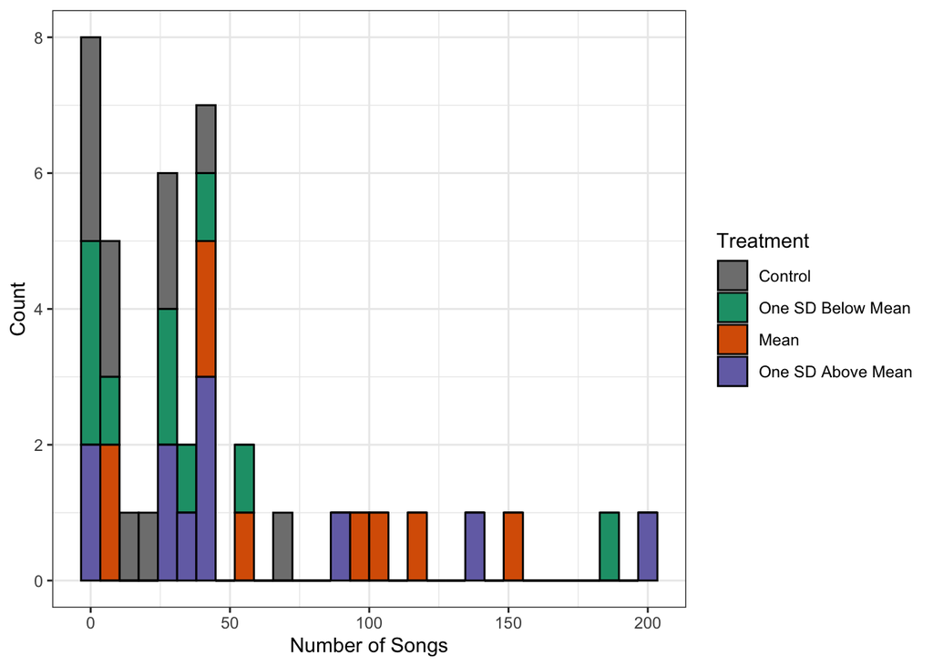

```r
ggplot(cleaned_summary_dataset, aes(x = number_of_songs, fill = treatment)) +
  geom_histogram(colour = "black") +
  labs(
    x = "Number of Songs",
    y = "Count",
    fill = "Treatment"
  ) +
  theme_bw() +
  scale_fill_manual(values = c("gray50", "#1b9e77", "#d95f02", "#7570b3"))
```

**Mean and Standard Deviation**

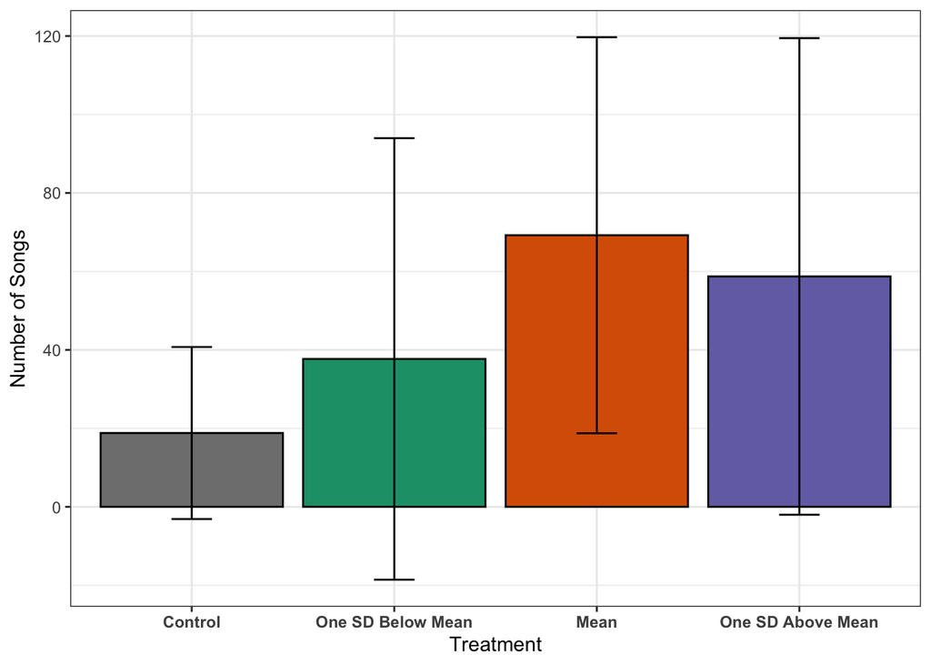

```r
ggplot(
  cleaned_summary_dataset,
  aes(x = treatment, y = number_of_songs, fill = treatment)
) +
  stat_summary(fun = mean, geom = "col", colour = "black") +
  stat_summary(
    fun.data = mean_sdl,
    fun.args = list(mult = 1),
    geom = "errorbar",
    width = 0.2
  ) +
  labs(
    x = "Treatment",
    y = "Number of Songs",
    fill = "Treatment"
  ) +
  scale_fill_manual(values = c("gray50", "#1b9e77", "#d95f02", "#7570b3"))+
  theme_bw() +
  theme(
    legend.position = "none",
    axis.text.x = element_text(face = "bold")
  )
```

**Median and Median Absolute Deviation**

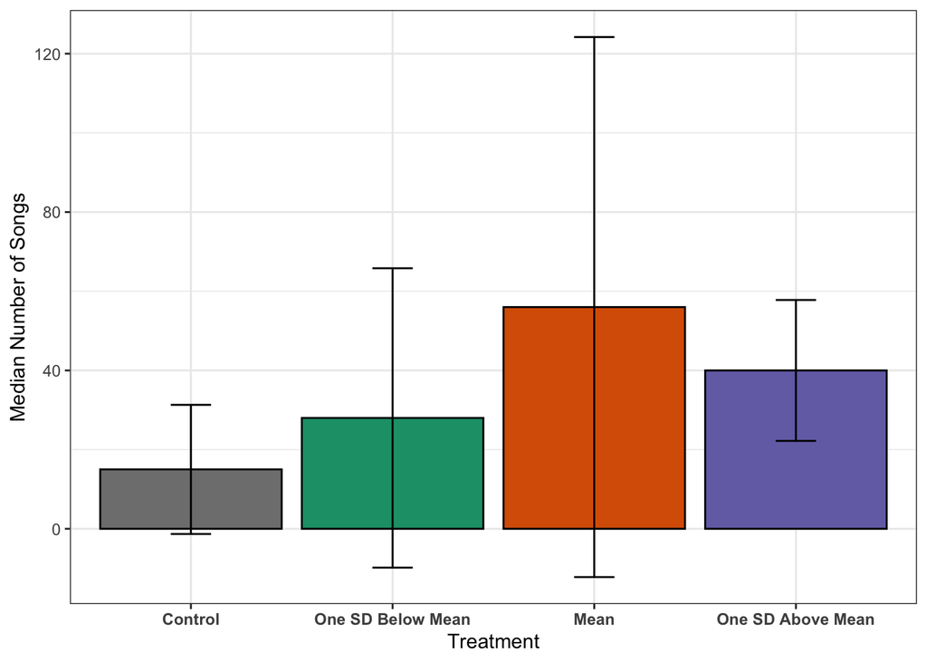

```r
ggplot(
  cleaned_summary_dataset,
  aes(x = treatment, y = number_of_songs, fill = treatment)
) +
  stat_summary(fun = median, geom = "col", colour = "black") +
  stat_summary(
    fun.data = function(x) {
      med = median(x, na.rm = TRUE)
      mad_val = mad(x, na.rm = TRUE)

      tibble(
        y = med,
        ymin = med - mad_val,
        ymax = med + mad_val
      )
    },
    geom = "errorbar",
    width = 0.2
  ) +
  labs(
    x = "Treatment",
    y = "Median Number of Songs",
    fill = "Treatment"
  ) +
  scale_fill_manual(values = c("gray50", "#1b9e77", "#d95f02", "#7570b3")) +
  theme_bw() +
  theme(
    legend.position = "none",
    axis.text.x = element_text(face = "bold")
  )
```

**Summary Statistics**

```r
numbers_for_summary_bar_charts = cleaned_summary_dataset %>%
  group_by(treatment) %>%
  summarise(
    total_songs = sum(number_of_songs, na.rm = TRUE),
    mean = mean(number_of_songs, na.rm = TRUE),
    standard_deviation = sd(number_of_songs, na.rm = TRUE),
    median = median(number_of_songs, na.rm = TRUE),
    median_absolute_deviation = mad(number_of_songs, na.rm = TRUE),
    .groups = "drop"
  )

glimpse(numbers_for_summary_bar_charts)
```

```
Rows: 4
Columns: 6
$ treatment                 <ord> Control, One SD Below Mean, Mean, One SD Abo…
$ total_songs               <int> 207, 377, 623, 646
$ mean                      <dbl> 18.81818, 37.70000, 69.22222, 58.72727
$ standard_deviation        <dbl> 21.92176, 56.27127, 50.46974, 60.73729
$ median                    <dbl> 15, 28, 56, 40
$ median_absolute_deviation <dbl> 16.3086, 37.8063, 68.1996, 17.7912
```

**Distribution by treatment**

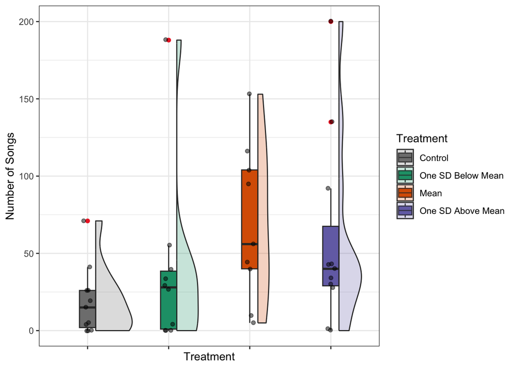

```r
ggplot(cleaned_summary_dataset, aes(x = treatment,y = number_of_songs)) +
  geom_boxplot(
    aes(fill = treatment),
    width = 0.2,
    outlier.colour = "firebrick2"
  ) +
  geom_violinhalf(
    aes(fill = treatment),
    alpha = 0.25,
    position = position_nudge(x = 0.10)
  ) +
  geom_jitter(alpha = 0.5, width = 0.05) +
  scale_fill_manual(values = c("gray50", "#1b9e77", "#d95f02", "#7570b3")) +
  labs(
    x = "Treatment",
    y = "Number of Songs",
    fill = "Treatment"
  ) +
  theme_bw() +
  theme(axis.text.x = element_blank())
```

## Individual Treatment Profiles

Plot each bird across treatments to visualize the repeated-measures structure.

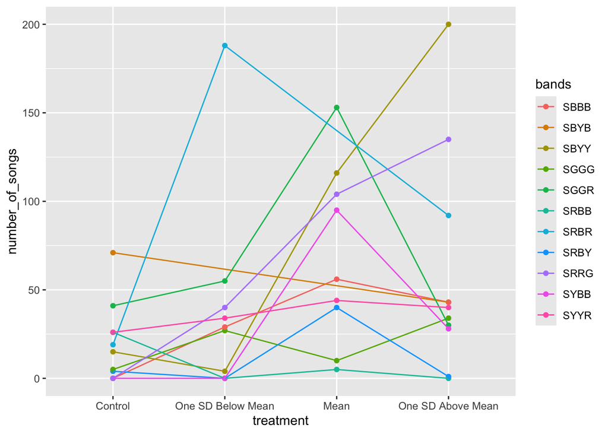

```r
ggplot(
  cleaned_summary_dataset,
  aes(
    x = treatment,
    y = number_of_songs,
    group = bands,
    color = bands
  )
) +
  geom_point() +
  geom_line()
```

## Song-Count Sensitivity to Extreme Observations

The following data set excludes observations outside 1.5 IQR of the treatment specific distribution. It is retained for visualization and sensitivity checks only; exclusion from formal analyses should require a biological or measurement-based justification.

```r
number_of_songs_no_outliers = cleaned_summary_dataset %>%
  group_by(treatment) %>%
  filter(
    number_of_songs >= quantile(number_of_songs, 0.25, na.rm = TRUE) - 1.5 * IQR(number_of_songs, na.rm = TRUE),
    number_of_songs <= quantile(number_of_songs, 0.75, na.rm = TRUE) + 1.5 * IQR(number_of_songs, na.rm = TRUE)
  ) %>%
  ungroup()
```

**Histogram Without Extreme Observations**

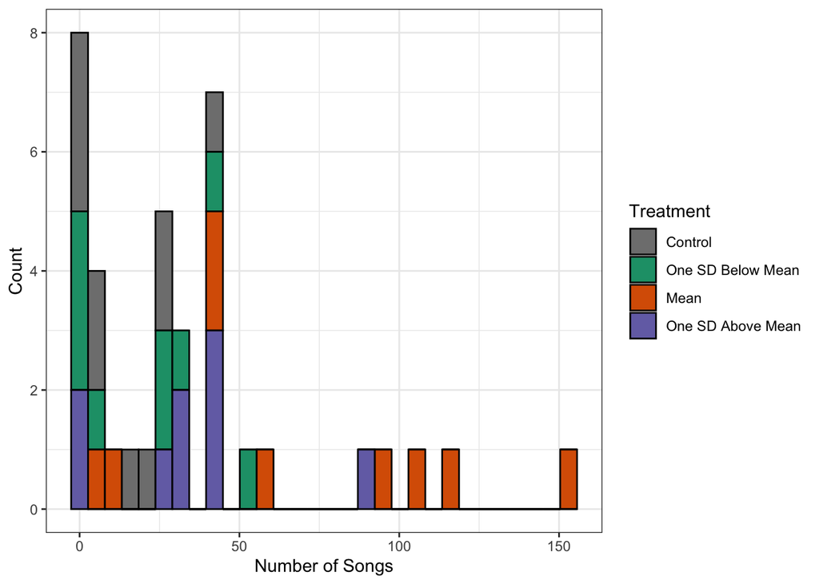

```r
ggplot(number_of_songs_no_outliers, aes(x = number_of_songs, fill = treatment)) +
  geom_histogram(colour = "black") +
  labs(
    x = "Number of Songs",
    y = "Count",
    fill = "Treatment"
  ) +
  theme_bw() +
  scale_fill_manual(values = c("gray50", "#1b9e77", "#d95f02", "#7570b3"))
```

**Mean and Standard Deviation Without Extreme Observations**

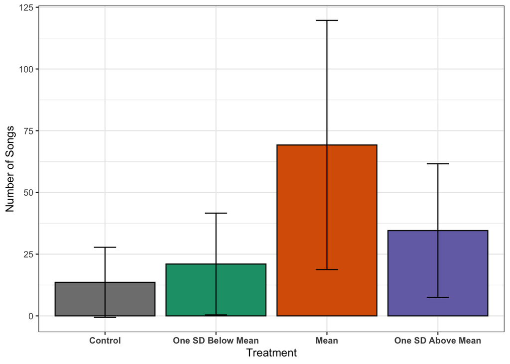

```r
ggplot(
  number_of_songs_no_outliers,
  aes(x = treatment, y = number_of_songs, fill = treatment)
) +
  stat_summary(fun = mean, geom = "col", colour = "black") +
  stat_summary(
    fun.data = mean_sdl,
    fun.args = list(mult = 1),
    geom = "errorbar",
    width = 0.2
  ) +
  labs(
    x = "Treatment",
    y = "Number of Songs",
    fill = "Treatment"
  ) +
  scale_fill_manual(values = c("gray50", "#1b9e77", "#d95f02", "#7570b3"))+
  theme_bw() +
  theme(
    legend.position = "none",
    axis.text.x = element_text(face = "bold")
  )
```

**Median and MAD Without Extreme Observations**

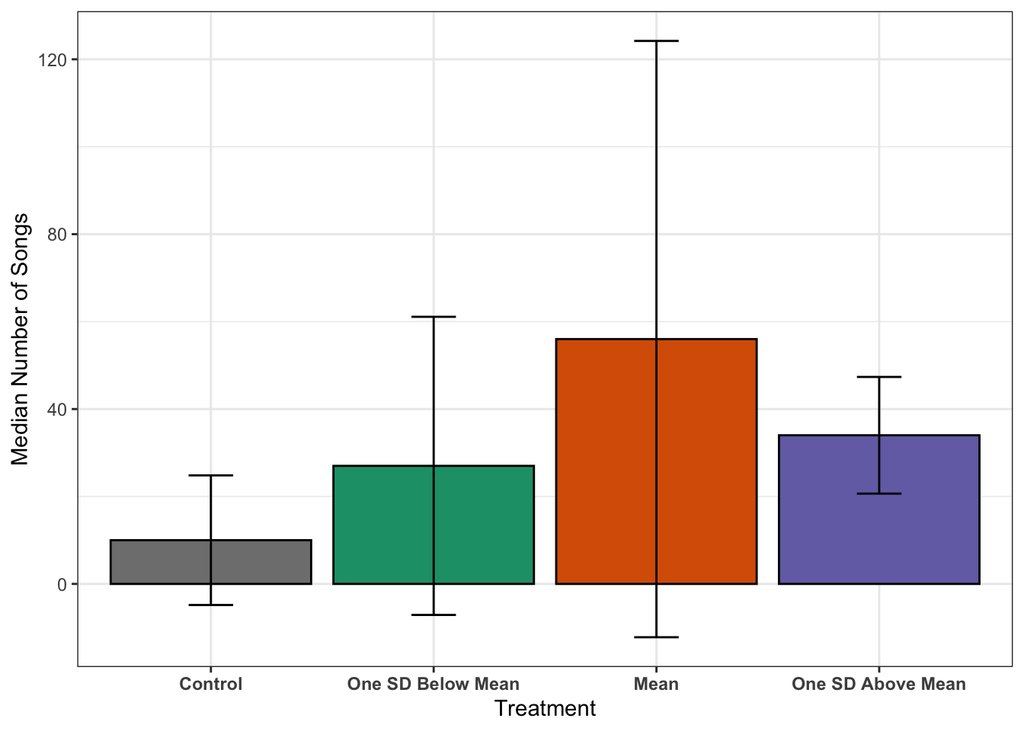

```r
ggplot(
  number_of_songs_no_outliers,
  aes(x = treatment, y = number_of_songs, fill = treatment)
) +
  stat_summary(fun = median, geom = "col", colour = "black") +
  stat_summary(
    fun.data = function(x) {
      med = median(x, na.rm = TRUE)
      mad_val = mad(x, na.rm = TRUE)

      tibble(
        y = med,
        ymin = med - mad_val,
        ymax = med + mad_val
      )
    },
    geom = "errorbar",
    width = 0.2
  ) +
  labs(
    x = "Treatment",
    y = "Median Number of Songs",
    fill = "Treatment"
  ) +
  scale_fill_manual(values = c("gray50", "#1b9e77", "#d95f02", "#7570b3")) +
  theme_bw() +
  theme(
    legend.position = "none",
    axis.text.x = element_text(face = "bold"))
```

**Summary Statistics Without Extreme Observations**

```r
numbers_for_summary_bar_charts_no_outliers = number_of_songs_no_outliers %>%
  group_by(treatment) %>%
  summarise(
    total_songs = sum(number_of_songs, na.rm = TRUE),
    mean = mean(number_of_songs, na.rm = TRUE),
    standard_deviation = sd(number_of_songs, na.rm = TRUE),
    median = median(number_of_songs, na.rm = TRUE),
    median_absolute_deviation = mad(number_of_songs, na.rm = TRUE),
    .groups = "drop"
  )

glimpse(numbers_for_summary_bar_charts_no_outliers)
```

```
Rows: 4
Columns: 6
$ treatment                 <ord> Control, One SD Below Mean, Mean, One SD Abo…
$ total_songs               <int> 136, 189, 623, 311
$ mean                      <dbl> 13.60000, 21.00000, 69.22222, 34.55556
$ standard_deviation        <dbl> 14.18293, 20.60946, 50.46974, 27.05601
$ median                    <dbl> 10, 27, 56, 34
$ median_absolute_deviation <dbl> 14.8260, 34.0998, 68.1996, 13.3434
```

**Distribution Without Extreme Observations**

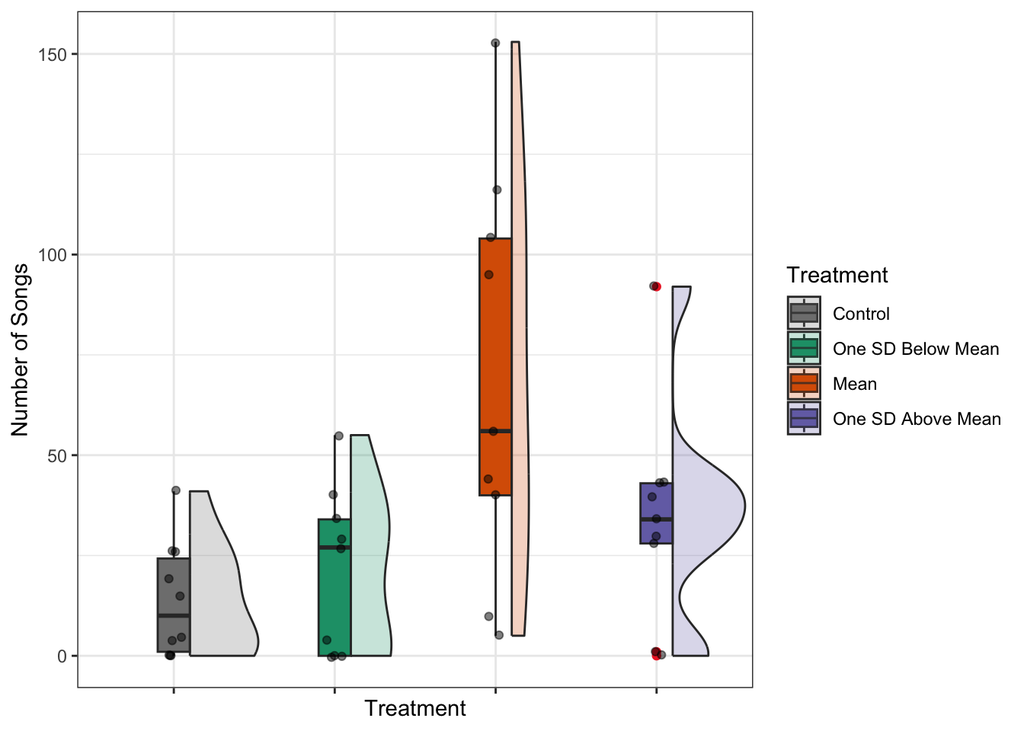

```r
ggplot(number_of_songs_no_outliers, aes(x = treatment,y = number_of_songs)) +
  geom_boxplot(
    aes(fill = treatment),
    width = 0.2,
    outlier.colour = "firebrick2"
  ) +
  geom_violinhalf(
    aes(fill = treatment),
    alpha = 0.25,
    position = position_nudge(x = 0.10)
  ) +
  geom_jitter(alpha = 0.5, width = 0.05) +
  scale_fill_manual(values = c("gray50", "#1b9e77", "#d95f02", "#7570b3")) +
  labs(
    x = "Treatment",
    y = "Number of Songs",
    fill = "Treatment"
  ) +
  theme_bw() +
  theme(axis.text.x = element_blank())
```

## Number of Songs While Within 10 Metres

**Overall Histogram**

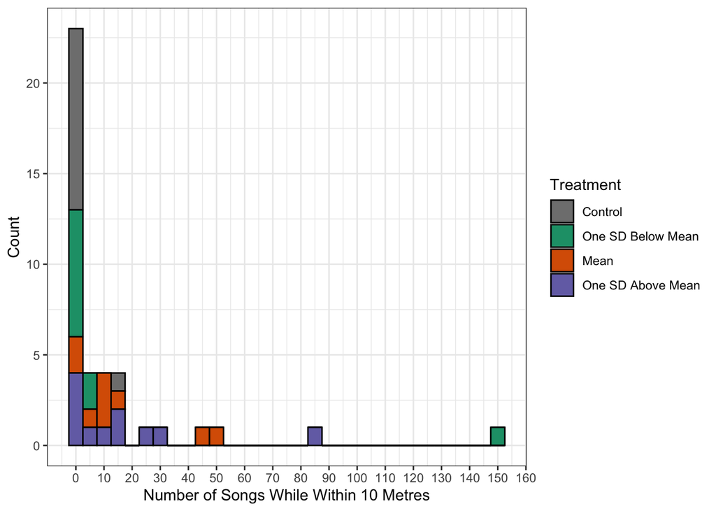

```r
ggplot(
  cleaned_summary_dataset,
  aes(x = number_of_songs_while_within_10_meters, fill = treatment)
) +
  geom_histogram(binwidth = 5, colour = "black") +
  labs(
    x = "Number of Songs While Within 10 Metres",
    y = "Count",
    fill = "Treatment"
  ) +
  scale_x_continuous(
    breaks = seq(
      0,
      ceiling(max(
        cleaned_summary_dataset$number_of_songs,
        na.rm = TRUE
        ) / 10) * 10,
      10
    )
  ) +
  theme_bw() +
  scale_fill_manual(values = c("gray50", "#1b9e77", "#d95f02", "#7570b3"))
```

**Total Songs by Treatment**

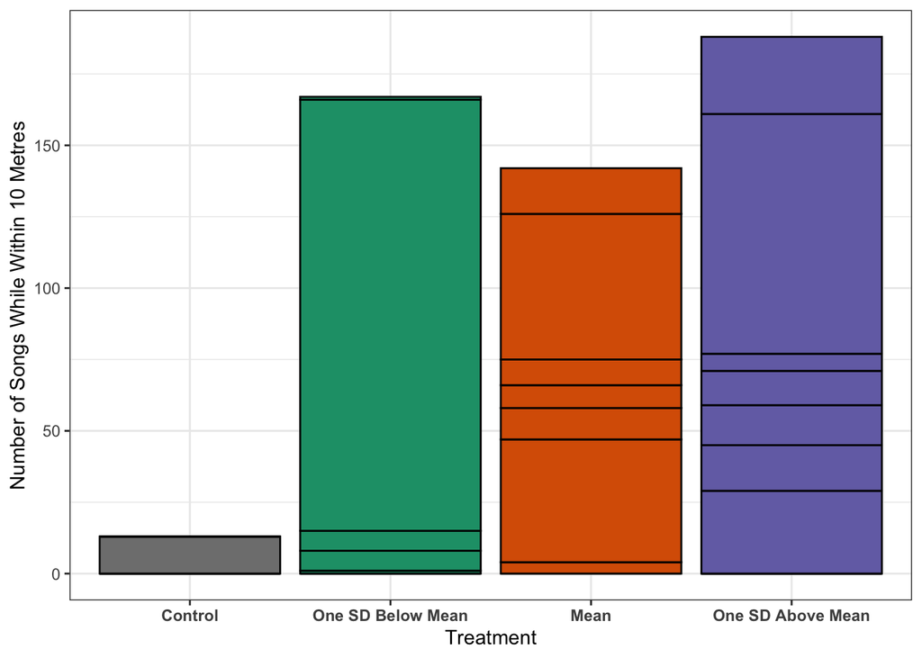

```r
ggplot(
  cleaned_summary_dataset,
  aes(
    x = treatment,
    y = number_of_songs_while_within_10_meters,
    fill = treatment
  )
) +
  geom_col(colour = "black") +
  labs(
    x = "Treatment",
    y = "Number of Songs While Within 10 Metres",
    fill = "Treatment"
  ) +
  scale_fill_manual(values = c("gray50", "#1b9e77", "#d95f02", "#7570b3"))+
  theme_bw() +
  theme(
    legend.position = "none",
    axis.text.x = element_text(face = "bold"))
```

**Treatment Totals**

```r
cleaned_summary_dataset %>%
  group_by(treatment) %>%
  summarise(
    total_songs_within_10_metres = sum(
      number_of_songs_while_within_10_meters,
      na.rm = TRUE
    ),
    .groups = "drop"
  )
```

```
# A tibble: 4 × 2
  treatment         total_songs_within_10_metres
  <ord>                                    <int>
1 Control                                     13
2 One SD Below Mean                          167
3 Mean                                       142
4 One SD Above Mean                          188
```

**Distribution by Treatment**

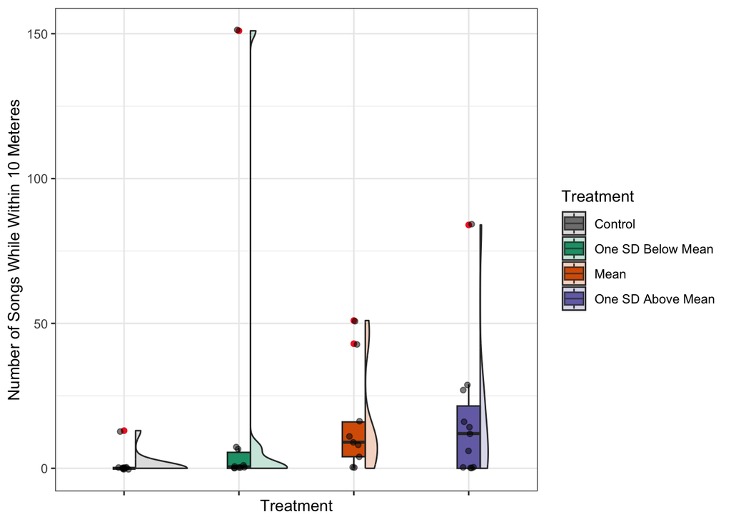

```r
ggplot(
  cleaned_summary_dataset,
  aes(x = treatment,y = number_of_songs_while_within_10_meters)
) +
  geom_boxplot(
    aes(fill = treatment),
    width = 0.2,
    outlier.colour = "firebrick2"
  ) +
  geom_violinhalf(
    aes(fill = treatment),
    alpha = 0.25,
    position = position_nudge(x = 0.10)
  ) +
  geom_jitter(alpha = 0.5, width = 0.05) +
  scale_fill_manual(values = c("gray50", "#1b9e77", "#d95f02", "#7570b3")) +
  labs(
    x = "Treatment",
    y = "Number of Songs While Within 10 Meteres",
    fill = "Treatment"
  ) +
  theme_bw() +
  theme(axis.text.x = element_blank())
```

## Focal Song Duration

Summarise focal-male song duration to examine variation among playback treatments and individual birds.

### Mean Song Duration by Treatment

```r
focal_duration_by_treatment = deju_data %>%
  filter(str_detect(annotation, "Focalsong")) %>%
  mutate(
    treatment = recode_factor(
      treatment,
      "Control" = "Control",
      "22" = "One SD Below Mean",
      "16" = "Mean",
      "10" = "One SD Above Mean",
      .ordered = TRUE
    )
  ) %>%
  group_by(bands, treatment) %>%
  summarise(mean_song_duration = mean(duration),
            sd_song_duration = sd(duration),
            .groups = "drop")
```

### Individual Treatment Profiles

Plot the mean focal song duration for each bird across playback treatments.

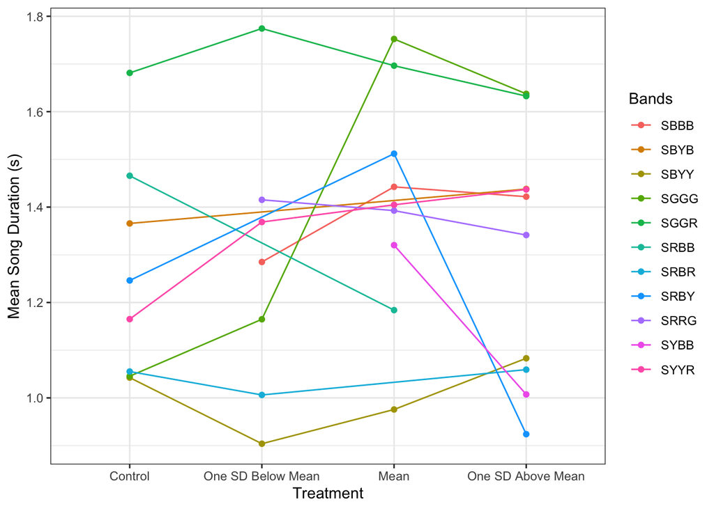

```r
ggplot(
  focal_duration_by_treatment,
  aes(x = treatment,
      y = mean_song_duration,
      group = bands,
      colour = bands
    )
) +
  geom_line() +
  geom_point() +
  labs(
    x = "Treatment",
    y = "Mean Song Duration (s)",
    colour = "Bands"
  ) +
  theme_bw()
```

### Bird Level Song Duration

Summarise focal-song duration across all treatments for each bird. standard errors are calculated from the number of songs produced by each bird.

```r
focal_duration_by_bird = deju_data %>%
  filter(str_detect(annotation, "Focalsong")) %>%
  group_by(bands) %>%
  summarise(
    mean_song_duration = mean(duration),
    sd_song_duration = sd(duration),
    se_song_duration = sd_song_duration/(sqrt(n())),
    number_of_songs = n(),
    .groups = "drop"
  )
```

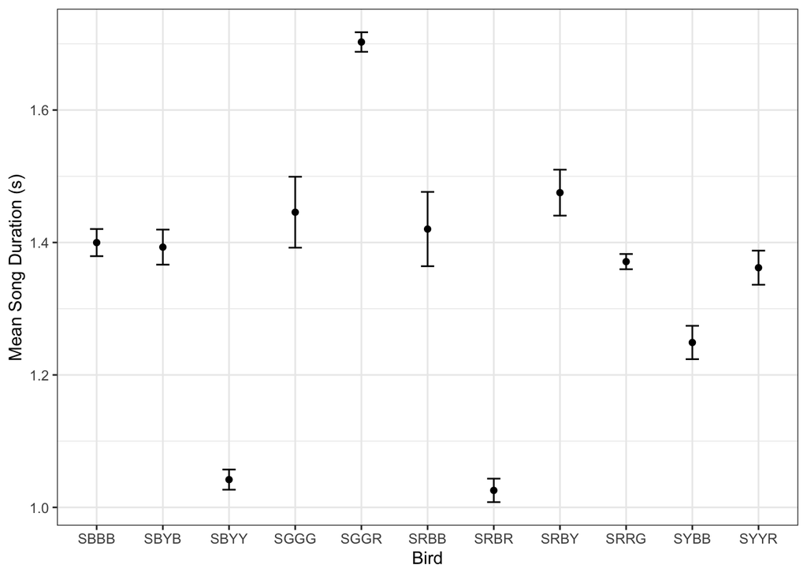

```r
ggplot(
  focal_duration_by_bird,
  aes(
    x = bands,
    y = mean_song_duration
  )
) +
  geom_point() +
  geom_errorbar(
    aes(
      ymin = mean_song_duration - se_song_duration,
      ymax = mean_song_duration + se_song_duration,
  ),
    width = 0.2
  ) +
  labs(
    x = "Bird",
    y = "Mean Song Duration (s)"
  ) +
  theme_bw()
```

# Song–Stimulus Overlap Analysis

## Analysis Rationale

Song–stimulus overlap was quantified following the general approach of Wilson et al. (2016). An overlap was defined as a focal-male song that began while a playback stimulus was already being broadcast. This directional definition evaluates whether focal males initiate songs during playback stimuli.

For each trial, the observed number of focal-song overlaps will be compared with the number expected if focal-song timing were independent of playback timing. Chance expectation is calculated from the playback duty cycle, defined as the proportion of the experimental playback period occupied by playback stimuli.

Because the playback experiment manipulated stimulus amplitude, focal songs used for the amplitude-related overlap analysis are restricted to songs produced while the focal male was estimated to be within 10 metres of the playback speaker. This restriction reduces variation in perceived playback amplitude caused by distance from the speaker.

## Define Playback Windows

Identify the beginning and end of the experimental playback period for each trial.

The beginning of the playback is identified by the `Pbstart` annotation. Most trials also contain a `Pbstop` annotation identifying the end of the playback. However, because `Pbstop` is missing from some trials, the offset of the final `Pbstim` annotation is used for the playback endpoint.

```r
playback_windows = deju_data %>%
  group_by(bands, treatment) %>%
  summarise(
    playback_start = first(onset[str_detect(annotation, "Pbstart")]),
    playback_end = last(offset[str_detect(annotation, "Pbstim")]),
    .groups = "drop"
  ) %>%
  mutate(playback_duration = playback_end - playback_start)
```

## Identify Playback Stimuli

Create one row for each playback stimulus. The annotation onset and offset define the interval during which the stimulus was playing.

```r
playback_stimuli = deju_data %>%
  filter(str_detect(annotation, "Pbstim")) %>%
  group_by(bands, treatment) %>%
  arrange(onset, .by_group = TRUE) %>%
  transmute(
    bands,
    treatment,
    stimulus_number = row_number(),
    stimulus_onset = onset,
    stimulus_offset = offset,
    stimulus_duration = duration
  ) %>%
  ungroup()
```

## Identify Focal Songs

Create one row for each focal-male song and retain its onset, offset, duration, and estimated distance from the playback speaker.

```r
focal_songs = deju_data %>%
  filter(str_detect(annotation, "Focalsong")) %>%
  group_by(bands, treatment) %>%
  arrange(onset, .by_group = TRUE) %>%
  transmute(
    bands,
    treatment,
    song_number = row_number(),
    song_onset = onset,
    song_offset = offset,
    song_duration = duration,
    estimated_distance_of_focal_male
  ) %>%
  ungroup()
```

## Define Eligible Focal Songs

Restrict the analysis to focal songs produced during the experimental playback period while the focal male was estimated to be within 10 metres of the playback speaker.

```r
eligible_focal_songs = focal_songs %>%
  left_join(playback_windows, by = c("bands", "treatment")) %>%
  filter(song_onset >= playback_start,
         song_onset <= playback_end,
         estimated_distance_of_focal_male <= 10)
```

## Classify Observed Overlaps

A focal song is classified as an overlap when its onset occurs after the beginning and before the end of a playback stimulus. Songs beginning outside all playback-stimulus intervals are classified as nonoverlaps.

```r
song_overlap_matches = eligible_focal_songs %>%
  inner_join(
    playback_stimuli,
    by = join_by(
      bands,
      treatment,
      song_onset >= stimulus_onset,
      song_onset < stimulus_offset
    )
  ) %>%
  select(
    bands,
    treatment,
    song_number,
    stimulus_number
  )
```

```r
song_level_overlap = eligible_focal_songs %>%
  left_join(
    song_overlap_matches,
    by = c("bands", "treatment", "song_number")
  ) %>%
  mutate(
    overlap = if_else(
    is.na(stimulus_number),
    0L,
    1L
  )
)
```

## Calculate Playback Duty Cycle

Calculate the proportion of each experimental playback period occupied by playback stimuli. Duty cycle represents the probability that a focal song beginning at a randomly selected time would begin during a playback stimulus.

```r
playback_duty_cycle = playback_stimuli %>%
  group_by(bands, treatment) %>%
  summarise(
    total_stimulus_time = sum(stimulus_duration, na.rm = TRUE),
    .groups = "drop"
  ) %>%
  left_join(
    playback_windows,
    by = c("bands", "treatment")
  ) %>%
  mutate(
    duty_cycle = total_stimulus_time / playback_duration
  )
```

## Summarise Observed Overlaps

For each bird-treatment trial, count the number of eligible focal songs, count the number that began during playback stimuli, and calculate the observed proportion of focal songs that overlapped playback.

```r
observed_overlaps = song_level_overlap %>%
  group_by(bands, treatment) %>%
  summarise(
    number_of_focal_songs = n(),
    observed_overlaps = sum(overlap),
    observed_overlap_proportion = mean(overlap),
    .groups = "drop"
  )
```

## Calculate Expected Overlap

Calculate the number of focal-song overlaps expected under random song timing. Expected overlap is the number of eligible focal songs multiplied by the playback duty cycle.

```r
trial_overlap_summary = playback_duty_cycle %>%
  left_join(
    observed_overlaps,
    by = c("bands", "treatment")
  ) %>%
  mutate(
    number_of_focal_songs = replace_na(
      number_of_focal_songs,
      0L
    ),
    observed_overlaps = replace_na(
      observed_overlaps,
      0L
    ),
    observed_overlap_proportion = if_else(
      number_of_focal_songs > 0,
      observed_overlaps / number_of_focal_songs,
      NA_real_
    ),
    expected_overlaps =
      number_of_focal_songs * duty_cycle,
    expected_overlap_proportion = duty_cycle,
    observed_expected_ratio = if_else(
      expected_overlaps > 0,
      observed_overlaps / expected_overlaps,
      NA_real_
    )
  )
```

## Inspect Observed and Expected Overlap

Summarise observed and expected overlap before fitting inferential models.

```r
trial_overlap_summary %>%
  filter(number_of_focal_songs > 0) %>%
  summarise(
    number_of_trials = n(),
    total_focal_songs = sum(number_of_focal_songs),
    total_observed_overlaps = sum(observed_overlaps),
    total_expected_overlaps = sum(expected_overlaps),
    median_observed_overlaps = median(observed_overlaps),
    median_expected_overlaps = median(expected_overlaps),
    median_observed_expected_ratio = median(
      observed_expected_ratio,
      na.rm = TRUE
    )
  )
```

```
# A tibble: 1 × 7
  number_of_trials total_focal_songs total_observed_overlaps
             <int>             <int>                   <int>
1               15               269                       4
# ℹ 4 more variables: total_expected_overlaps <dbl>,
#   median_observed_overlaps <int>, median_expected_overlaps <dbl>,
#   median_observed_expected_ratio <dbl>
```

```r
trial_overlap_summary %>%
  filter(number_of_focal_songs > 0) %>%
  group_by(treatment) %>%
  summarise(
    number_of_trials = n(),
    total_focal_songs = sum(number_of_focal_songs),
    total_observed_overlaps = sum(observed_overlaps),
    total_expected_overlaps = sum(expected_overlaps),
    median_observed_overlaps = median(observed_overlaps),
    median_expected_overlaps = median(expected_overlaps),
    median_observed_expected_ratio = median(
      observed_expected_ratio,
      na.rm = TRUE
    ),
    .groups = "drop"
  )
```

```
# A tibble: 4 × 8
  treatment number_of_trials total_focal_songs total_observed_overlaps
  <chr>                <int>             <int>                   <int>
1 10                       7               134                       1
2 16                       4                51                       1
3 22                       3                71                       2
4 Control                  1                13                       0
# ℹ 4 more variables: total_expected_overlaps <dbl>,
#   median_observed_overlaps <dbl>, median_expected_overlaps <dbl>,
#   median_observed_expected_ratio <dbl>
```